# LIS 490 HomeWork3

Kefu Zhu, kefuzhu2

Wednesday, September 17, 2016

HW 3 - Due Tuesday Sept 20, 2016. Upload R file to Moodle with name:HW3_490IDS_YOURNETID.R

Do Not remove any of the comments. These are marked by # The .R file will contain your code and answers to questions.

Name: Kefu Zhu

Main topic: Using the “apply” family function

# Q1 (5 pts)

Given a function below,

```r
myfunc <- function(z) return(c(z,z^2, z^3%/%2))
```

## (1)

Examine the following code, and briefly explain what it is doing.

```r
y = 2:8
```

**Answer**: It creates a list of integers from 2 to 8 and stores the list in variable y.

```r
myfunc(y)
```

```
##  [1]   2   3   4   5   6   7   8   4   9  16  25  36  49  64   4  13  32
## [18]  62 108 171 256
```

**Answer**: For each element in list y, myfunc turns it into three three elements: the original element, the square of it, and the integer division value of the cubic value divided by 2.

```r
matrix(myfunc(y), ncol = 3)
```

```
##      [,1] [,2] [,3]
## [1,]    2    4    4
## [2,]    3    9   13
## [3,]    4   16   32
## [4,]    5   25   62
## [5,]    6   36  108
## [6,]    7   49  171
## [7,]    8   64  256
```

Your explanation

**Answer**: It transform the list-presented value from myfunc(y) to a matrix with 3 colummns, where each row represents the outputs from an original element in y

## (2)

Simplify the code in (1) using one of the “apply” functions and save the result as m.

code & result

```r
m <- t(sapply(y, myfunc))
```

## (3)

Find the row product of m.

code & result

```r
apply(m, 1, prod)
```

```
## [1]     32    351   2048   7750  23328  58653 131072
```

## (4)

Find the column sum of m in two ways.

code & result

```r
apply(m, 2, sum)
```

```
## [1]  35 203 646
```

```r
colSums(m)
```

```
## [1]  35 203 646
```

## (5)

Could you divide all the values by 2 in two ways?

code & result

```r
matrix(sapply(m, function(x) return(x / 2)), ncol = 3)
```

```
##      [,1] [,2]  [,3]
## [1,]  1.0  2.0   2.0
## [2,]  1.5  4.5   6.5
## [3,]  2.0  8.0  16.0
## [4,]  2.5 12.5  31.0
## [5,]  3.0 18.0  54.0
## [6,]  3.5 24.5  85.5
## [7,]  4.0 32.0 128.0
```

```r
sweep(m, 2, 2, "/")
```

```
##      [,1] [,2]  [,3]
## [1,]  1.0  2.0   2.0
## [2,]  1.5  4.5   6.5
## [3,]  2.0  8.0  16.0
## [4,]  2.5 12.5  31.0
## [5,]  3.0 18.0  54.0
## [6,]  3.5 24.5  85.5
## [7,]  4.0 32.0 128.0
```

# Q2 (8 pts)

Create a list with 2 elements as follows:

```r
l <- list(a = 1:10, b = 11:20)
```

## (1)

What is the product of the values in each element?

```r
sapply(l, prod)
```

```
##            a            b
##      3628800 670442572800
```

## (2)

What is the (sample) variance of the values in each element?

```r
sapply(l, var)
```

```
##        a        b
## 9.166667 9.166667
```

## (3)

What type of object is returned if you use lapply? sapply? Show your R code that finds these answers.

```r
class(sapply(l,var))
```

```
## [1] "numeric"
```

```r
class(lapply(l,var))
```

```
## [1] "list"
```

Now create the following list:

```r
l.2 <- list(c = c(21:30), d = c(31:40))
```

## (4)

What is the sum of the corresponding elements of l and l.2, using one function call?

```r
mapply('+', l, l.2)
```

```
##        a  b
##  [1,] 22 42
##  [2,] 24 44
##  [3,] 26 46
##  [4,] 28 48
##  [5,] 30 50
##  [6,] 32 52
##  [7,] 34 54
##  [8,] 36 56
##  [9,] 38 58
## [10,] 40 60
```

## (5)

Take the log of each element in the list l:

```r
sapply(l, log)
```

```
##               a        b
##  [1,] 0.0000000 2.397895
##  [2,] 0.6931472 2.484907
##  [3,] 1.0986123 2.564949
##  [4,] 1.3862944 2.639057
##  [5,] 1.6094379 2.708050
##  [6,] 1.7917595 2.772589
##  [7,] 1.9459101 2.833213
##  [8,] 2.0794415 2.890372
##  [9,] 2.1972246 2.944439
## [10,] 2.3025851 2.995732
```

## (6)

First change l and l.2 into matrixes, make each element in the list as column,

your code here

```r
l <- sapply(l, matrix)
l.2 <- sapply(l.2, matrix)
```

Then, form a list named mylist using l,l.2 and m (from Q1) (in this order).

your code here

```r
mylist <- list(l, l.2, m)
```

Then, select the first column of each elements in mylist in one function call (hint ‘[’ is the select operator).

your code here

```r
rapply(mylist, classes = 'matrix', how = 'list', f = function(x) x[, 1, drop = FALSE])
```

```
## [[1]]
##        a
##  [1,]  1
##  [2,]  2
##  [3,]  3
##  [4,]  4
##  [5,]  5
##  [6,]  6
##  [7,]  7
##  [8,]  8
##  [9,]  9
## [10,] 10
##
## [[2]]
##        c
```

[output cut: 20 more lines]

# Q3 (3 pts)

Let’s load our friend family data again.

```r
load(url("http://courseweb.lis.illinois.edu/~jguo24/family.rda"))
```

## (1)

Find the mean bmi by gender in one function call.

```r
aggregate(fbmi ~ fgender, data = data.frame(fbmi, fgender), mean)
```

```
##   fgender     fbmi
## 1       m 25.73898
## 2       f 23.02564
```

## (2)

Could you get a vector of what the type of variables the dataset is made of?

```r
sapply(family,class)
```

```
## firstName    gender       age    height    weight       bmi    overWt
##  "factor"  "factor" "integer" "numeric" "integer" "numeric" "logical"
```

## (3)

Could you sort the firstName in height descending order?

```r
data.frame(fnames,fheight)[order(data.frame(fnames,fheight)$fheight),]$fnames
```

```
##  [1] Zoe May Sue Sal Dan Art Bob Ann Liz Jon Tim Tom Tom Joe
## Levels: Ann Art Bob Dan Joe Jon Liz May Sal Sue Tim Tom Zoe
```

# Q4 (2 pts)

There is a famous dataset in R called “iris.” It should already be loaded in R for you. If you type in ?iris you can see some documentation. Familiarize yourself with this dataset.

## (1)

Find the mean petal length by species.

code & result

```r
aggregate(Petal.Length ~ Species, data = iris, mean)
```

```
##      Species Petal.Length
## 1     setosa        1.462
## 2 versicolor        4.260
## 3  virginica        5.552
```

## (2)

Now obtain the sum of the first 4 variables, by species, but using only one function call.

code & result

```r
aggregate(. ~ Species, data = iris, sum)
```

```
##      Species Sepal.Length Sepal.Width Petal.Length Petal.Width
## 1     setosa        250.3       171.4         73.1        12.3
## 2 versicolor        296.8       138.5        213.0        66.3
## 3  virginica        329.4       148.7        277.6       101.3
```

# Q5 (2 pts)

Below are two statements, their results have different structure,

```r
lapply(1:4, function(x) x^3)
```

```
## [[1]]
## [1] 1
##
## [[2]]
## [1] 8
##
## [[3]]
## [1] 27
##
## [[4]]
## [1] 64
```

```r
sapply(1:4, function(x) x^3)
```

```
## [1]  1  8 27 64
```

Could you change one of them to make the two statements return the same results (type of object)?

```r
unlist(lapply(1:4, function(x) x ^ 3))
```

```
## [1]  1  8 27 64
```

# Q6. (5 pts)

Using the family data, fit a linear regression model to predict weight from height. Place your code and output (the model) below.

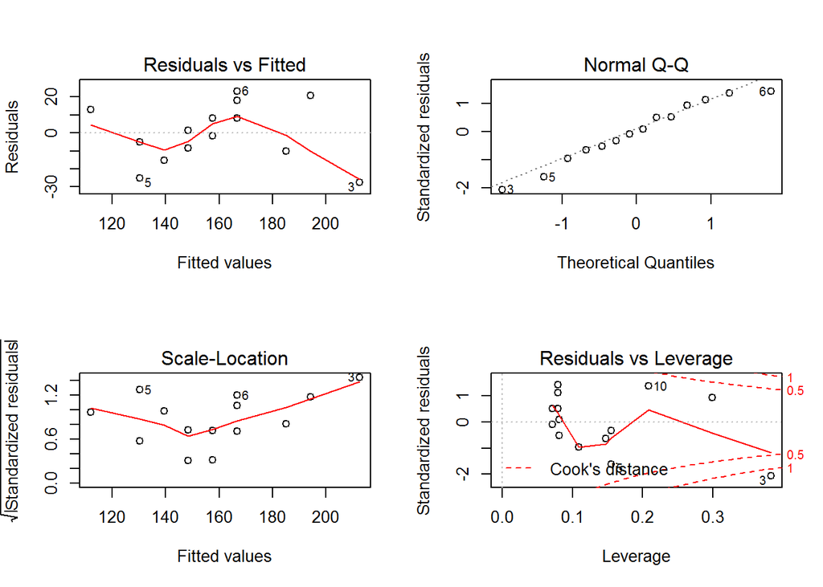

```r
fit <- lm(fweight ~ fheight)
par(mfrow = c(2, 2))
plot(fit)
```

```r
summary(fit)
```

```
##
## Call:
## lm(formula = fweight ~ fheight)
##
## Residuals:
##     Min      1Q  Median      3Q     Max
## -27.554  -9.689  -0.055  11.944  23.214
##
## Coefficients:
##             Estimate Std. Error t value Pr(>|t|)
## (Intercept) -455.666    107.029  -4.257  0.00111 **
## fheight        9.154      1.594   5.741 9.29e-05 ***
## ---
## Signif. codes:  0 '***' 0.001 '**' 0.01 '*' 0.05 '.' 0.1 ' ' 1
##
## Residual standard error: 16.94 on 12 degrees of freedom
## Multiple R-squared:  0.7331, Adjusted R-squared:  0.7109
## F-statistic: 32.96 on 1 and 12 DF,  p-value: 9.287e-05
```

How do you interpret this model?

**Answer**: Based on the previous diagnostic plots, no assumptions are obviously violated. The linear model is valid. Based on the summary of fitted linear model, the weight of a person is expected to increase by 9.154 units if the height of that person is increased by 1 unit.

Create a scatterplot of height vs weight. Add the linear regression line you found above.

[figure not shown]

```r
par(mfrow = c(1, 1))
plot(fweight ~ fheight, xlab = 'Weight', ylab = 'Height')
abline(fit)
```

Provide an interpretation for your plot.

**Answer**: The plot indicates a positive linear relationship between fheight and fweight. And the line in the plot is the best fitted linear regression model with least sum of square of residuals.